# L9 回归模型和变量选择

Wangcheng Li

2023-11-01

# 1 L9 回归模型和变量选择

## 1.1 多元线性回归模型

多元线性回归模型是回归问题中最基本也是最常用的模型，模型的基本假定是响应变量Y关于自变量X的条件期望是X的线性函数：

$$E(Y\mid X ) = g(X,\beta) = \beta_0 + \sum_{j=1}^{p}\beta_j X_j.$$

使用最小二乘的思路计算 $\beta$ 的估计值：

$$\beta^* = \arg\min_\beta \mathbf E \bigg(Y-g(X,\beta)\bigg)^2.$$

其样本形式为

$$\hat\beta = \arg\min_\beta \sum_{i=1}^{n}\bigg(Y_i -
\sum_{j=1}^{p}\beta_j X_j \bigg)^2.$$

其矩阵形式为

$$\hat\beta = \arg\min_\beta ||\mathbf Y-\mathbf X\beta||_2^2.$$

这里粗体的 $\mathbf X$ 和 $\mathbf Y$ 均为样本矩阵。利用多元函数求导法则，并分别验证一阶、二阶导条件，可以得到上面的这个优化问题的解析解：

$$\hat\beta = (\mathbf X^T \mathbf X)^{-1} \mathbf X^T \mathbf Y$$

基于此，我们可以在R语言中手动进行线性模型的估计。

### 1.1.1 手动实现

```r
# 生成数据
Sig = matrix(0,7,7)
for(i in 1:7){
  for(j in 1:7){
    Sig[i,j] = 0.5**abs(i-j)
  }
}
mu = rep(0,7)
X = mvrnorm(100,rep(0,7),Sig)
y = X %*% c(1,-1,0.5,-0.5,0.1,-0.1,0) + rnorm(100)
```

使用矩阵形式的解析解来计算 $beta$ 的估计值：

```r
beta.hat = solve(t(X)%*%X)%*%t(X)%*%y
print(beta.hat)
```

```
##             [,1]
## [1,]  1.11298635
## [2,] -1.00771074
## [3,]  0.51701958
## [4,] -0.47011054
## [5,]  0.11945983
## [6,] -0.02650927
## [7,] -0.14931777
```

由于我们通常还关心统计推断问题，因此我们需要 $\hat \beta$ 的方差估计。在此之前，我们需要估计 $Var(\epsilon|X)$ ，即误差项的方差。

```r
sigma.hat = sum((X%*%beta.hat - y)**2)/(100-7)
print(sigma.hat)
```

```
## [1] 0.8717253
```

由于 $\hat\beta = (X^T X)^{-1}X^T Y = \beta + (X^T X)^{-1}X^T \epsilon$ ，因此 $\hat\beta \sim N(\beta,var((X^T X)^{-1}X^T \epsilon)$.将方差项重写，得到 $(X^T X)^{-1} \sigma^2$，其中 $\sigma^2 = Var(\epsilon \mid X)$.

```r
var.hat = solve(t(X)%*%X)*sigma.hat
print(var.hat)
```

```
##               [,1]          [,2]          [,3]          [,4]          [,5]
## [1,]  1.386336e-02 -0.0078952012 -0.0007220319  4.175889e-05 -0.0005763064
## [2,] -7.895201e-03  0.0178474595 -0.0066079795 -5.815199e-04  0.0022520979
## [3,] -7.220319e-04 -0.0066079795  0.0143361054 -4.394695e-03 -0.0022470193
## [4,]  4.175889e-05 -0.0005815199 -0.0043946952  1.469310e-02 -0.0044805671
## [5,] -5.763064e-04  0.0022520979 -0.0022470193 -4.480567e-03  0.0149493271
## [6,]  1.137381e-03 -0.0016294317  0.0019858061 -3.108868e-04 -0.0046931707
## [7,] -3.850221e-04  0.0013381450 -0.0001899258 -5.093998e-04 -0.0016592619
##               [,6]          [,7]
## [1,]  0.0011373810 -0.0003850221
## [2,] -0.0016294317  0.0013381450
## [3,]  0.0019858061 -0.0001899258
## [4,] -0.0003108868 -0.0005093998
## [5,] -0.0046931707 -0.0016592619
## [6,]  0.0146488708 -0.0041898088
## [7,] -0.0041898088  0.0103240903
```

此外，我们也可以计算$R^2$和调整$R^2$.

```r
(rsq = 1-sum((X%*%beta.hat - y)**2)/sum((y-mean(y))**2))
```

```
## [1] 0.5769719
```

```r
(arsq = 1-sum((X%*%beta.hat - y)**2)/sum((y-mean(y))**2)*(100-1)/(100-7))
```

```
## [1] 0.5496797
```

```r
print(rsq);print(arsq)
```

```
## [1] 0.5769719
```

```
## [1] 0.5496797
```

### 1.1.2 R语言的实现

显然，如此基本的函数在 R 语言里面也有相应的实现，R语言自带包 `stat` 中有函数 `lm` 可以实现多元线性回归模拟的计算。

```r
md = lm(y~X-1)
summary(md)
```

```
##
## Call:
## lm(formula = y ~ X - 1)
##
## Residuals:
##      Min       1Q   Median       3Q      Max
## -2.39289 -0.71243 -0.00943  0.52769  1.68782
##
## Coefficients:
##    Estimate Std. Error t value Pr(>|t|)
## X1  1.11299    0.11774   9.453 2.94e-15 ***
## X2 -1.00771    0.13359  -7.543 3.02e-11 ***
## X3  0.51702    0.11973   4.318 3.93e-05 ***
## X4 -0.47011    0.12122  -3.878 0.000196 ***
## X5  0.11946    0.12227   0.977 0.331085
## X6 -0.02651    0.12103  -0.219 0.827110
## X7 -0.14932    0.10161  -1.470 0.145057
## ---
## Signif. codes:  0 '***' 0.001 '**' 0.01 '*' 0.05 '.' 0.1 ' ' 1
##
## Residual standard error: 0.9337 on 93 degrees of freedom
## Multiple R-squared:  0.5776, Adjusted R-squared:  0.5458
## F-statistic: 18.17 on 7 and 93 DF,  p-value: 5.075e-15
```

与上面进行对比，发现R方的计算结果不一致，这主要是因为不考虑截距项的R方的计算方式不一样。

```r
rsq_lm = 1-mean(md$residuals**2)/mean(y**2)
arsq_lm = 1-mean(md$residuals**2)/mean(y**2)*(100)/(100-7)
```

## 1.2 变量选择

在实际问题中，变量选择是一个非常重要的步骤。通常来说，我们在最初建模时，会在模型中放入尽可能多的变量，因为我们并不知道哪些变量对响应变量Y有作用。而后，出于预测能力和模型可解释性的考量，我们会仅选择一部分变量建立最终的模型。因此，如何选择真正重要的变量是统计学研究中经久不衰的一个问题。

### 1.2.1 子集选择

子集选择的3个经典做法是：

- 最优子集选择
- 向前逐步回归
- 向后逐步回归

#### 1.2.1.1 最优子集选择

最优子集选择的思路很简单，即比较所有可能的子模型，并依据某一指标选择所有子模型中最优的模型。选择的指标应当保证，纳入无关变量会使得模型的指标下降的同时，纳入重要变量会使得指标上升。可供使用的指标包括调整R方、交叉验证下的预测误差等。总的思路是对模型复杂度进行惩罚。

算法的思路为：

- 循环每一个子模型
- 对每一个子模型计算预先选择的指标
- 选择指标最优的子模型

```r
library(MASS)

Sig = matrix(0,7,7)
for(i in 1:7){
  for(j in 1:7){
    Sig[i,j] = 0.5**abs(i-j)
  }
}
mu = rep(0,7)
X = mvrnorm(100,rep(0,7),Sig)
y = X %*% c(1,-1,0.5,-0.5,0.1,-0.1,0) + rnorm(100)

n = 100;id_train = sort(sample(1:n,n*0.7))

cur_mse = var(y)
cur_comb = numeric(0)
for(p in 1:7){
  all_possible = combn(1:7,p)
  num_possible = ncol(all_possible)

  for(j in 1:num_possible){
    X_part = X[,all_possible[,j],drop = F]
    dt = as.data.frame(cbind(X_part,y))
    colnames(dt) = c(paste0("x",1:p),"y")
    md_part = lm(y~.,data = dt)
    yhat = predict(md_part,newdata = dt)
    mse = mean(((yhat-y)**2)[-id_train])
    if(mse < cur_mse){
      cur_comb = all_possible[,j]
      cur_mse  = mse
    }
  }
}
cur_comb
```

```
## [1] 1 2 3 4 6 7
```

#### 1.2.1.2 向前/向后逐步回归

显然，最优子集选择的计算量非常大，尤其是当变量维数非常高的时候。一个替代的做法是向前/向后逐步回归。以向前逐步回归为例，我们从一个零模型开始（即不选择任何变量），而后在零模型的基础上逐步增加变量，每次增加一个。增加变量时，我们选择能使模型指标最优的变量进入模型。当模型指标稳定时，我们不再增加变量。

```r
cur_comb = numeric(0)
cur_mse = var(y[-id_train])
for(p in 1:7){
  new_mse = cur_mse
  new_comb = NA

  not_in = (1:7)[-cur_comb]
  if(length(cur_comb)==0){not_in=1:7}
  for(j in 1:length(not_in)){
    # j = 2
    ind = c(cur_comb,not_in[j])
    dt = as.data.frame(cbind(X[,ind],y))
    colnames(dt) = c(paste0("x",1:length(ind)),"y")
    md_part = lm(y~.,data = dt[id_train,])
    yhat = predict(md_part,newdata = dt)
    mse = mean(((yhat-y)**2)[-id_train])
    if(mse < new_mse){
      new_mse = mse
      new_comb = ind
    }
  }
  if(cur_mse == new_mse){
    message("stop")
    break
  }
  cur_comb = new_comb
}
cur_comb
```

```
## [1] 2 1 3 4 5 7 6
```

### 1.2.2 惩罚估计

子集选择的一个问题是，当变量维数增加时，计算复杂度会快速增加。即使是向前/向后逐步回归，计算复杂度也会是变量维数的平方倍。此时，另外一个选择是使用惩罚估计。线性模型下两种常见的惩罚估计是岭回归和LASSO回归，这两种方法在R语言中都有相应的R包用于实现。

#### 1.2.2.1 岭回归和LASSO回归在R语言中的实现

```r
library(glmnet)
```

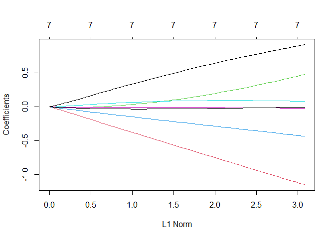

```r
md.glm = glmnet(X,y,"gaussian",alpha = 0)
plot(md.glm)
```

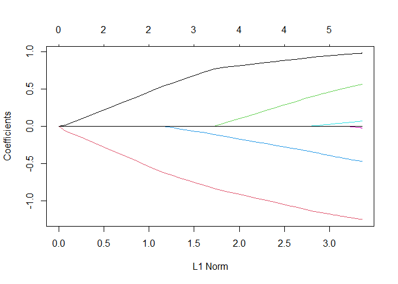

```r
md.glm = glmnet(X,y,"gaussian",alpha = 1)
plot(md.glm)
```